# Unsupervised Clustering Case Study – Penguin Segmentation

## 4. Select K (number of clusters)

We use:

- **Elbow Method** (inertia)
- **Silhouette Score** (higher is better)

This avoids hardcoding `k=4` and makes the notebook more credible.

```python
k_values = range(2, 11)
inertias = []
sil_scores = []

for k in k_values:
    kmeans = KMeans(n_clusters=k, random_state=42, n_init=10)
    labels = kmeans.fit_predict(X_prepared)
    inertias.append(kmeans.inertia_)
    sil_scores.append(silhouette_score(X_prepared, labels))

best_k = k_values[int(np.argmax(sil_scores))]
best_k
```

```
2
```

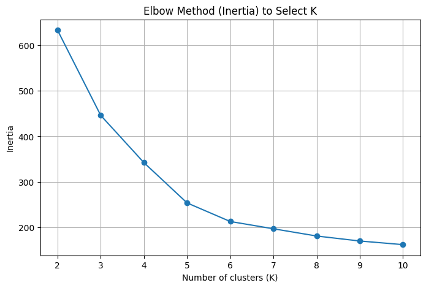

```python
plt.figure(figsize=(8, 5))
plt.plot(list(k_values), inertias, marker="o")
plt.title("Elbow Method (Inertia) to Select K")
plt.xlabel("Number of clusters (K)")
plt.ylabel("Inertia")
plt.xticks(list(k_values))
plt.grid(True)
plt.show()
```

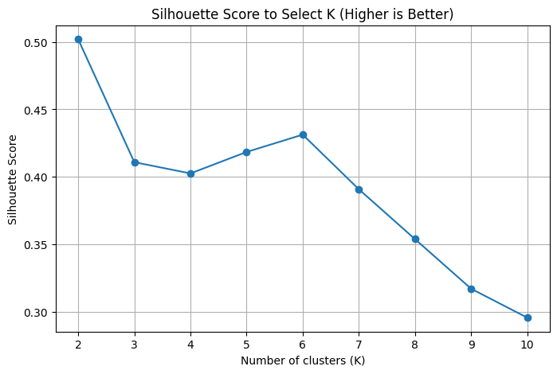

```
Best K by silhouette score: 2
```

```python
plt.figure(figsize=(8, 5))
plt.plot(list(k_values), sil_scores, marker="o")
plt.title("Silhouette Score to Select K (Higher is Better)")
plt.xlabel("Number of clusters (K)")
plt.ylabel("Silhouette Score")
plt.xticks(list(k_values))
plt.grid(True)
plt.show()

print(f"Best K by silhouette score: {best_k}")
```

## 5. Fit final K-Means model

```python
final_k = best_k  # you can manually override this if needed
kmeans_final = KMeans(n_clusters=final_k, random_state=42, n_init=10)
clusters = kmeans_final.fit_predict(X_prepared)

df_result = df_clean.copy()
df_result["Cluster"] = clusters
df_result.head()
```

|  | culmen_length_mm | culmen_depth_mm | flipper_length_mm | body_mass_g | sex | Cluster |
| --- | --- | --- | --- | --- | --- | --- |
| 0 | 39.1 | 18.7 | 181.0 | 3750.0 | MALE | 0 |
| 1 | 39.5 | 17.4 | 186.0 | 3800.0 | FEMALE | 0 |
| 2 | 40.3 | 18.0 | 195.0 | 3250.0 | FEMALE | 0 |
| 3 | 36.7 | 19.3 | 193.0 | 3450.0 | FEMALE | 0 |
| 4 | 39.3 | 20.6 | 190.0 | 3650.0 | MALE | 0 |

## 6. Visualise clusters using PCA (2D)

We reduce the prepared feature matrix to 2 dimensions and plot the clusters.

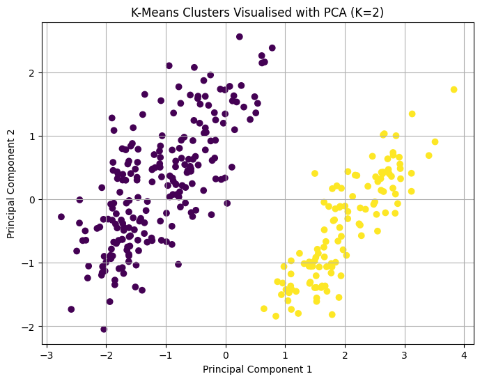

```python
pca = PCA(n_components=2, random_state=42)
X_pca = pca.fit_transform(X_prepared)

plt.figure(figsize=(8, 6))
scatter = plt.scatter(X_pca[:, 0], X_pca[:, 1], c=clusters)
plt.title(f"K-Means Clusters Visualised with PCA (K={final_k})")
plt.xlabel("Principal Component 1")
plt.ylabel("Principal Component 2")
plt.grid(True)
plt.show()
```

## 7. Cluster summary statistics

We summarise numeric features by cluster to interpret how clusters differ.

```python
summary = df_result.groupby("Cluster")[numeric_features].mean().round(2)
summary
```

| Cluster | culmen_length_mm | culmen_depth_mm | flipper_length_mm | body_mass_g |
| --- | --- | --- | --- | --- |
| 0 | 42.04 | 18.36 | 191.89 | 3711.50 |
| 1 | 47.57 | 15.00 | 217.24 | 5092.44 |

## 8. Quick interpretation guide

- Look for clusters separated mainly by **body_mass_g** and **flipper_length_mm** (often strong differentiators).
- If one cluster has consistently higher body mass and flipper length, it may represent a distinct group.
- If clusters overlap in PCA space, the species/segments may have similar measurements.

## Next Improvements (Optional)

- Add imputation rather than dropping missing values
- Try alternative clustering methods (GMM, DBSCAN)
- Add cluster profiling including categorical proportions (e.g., sex distribution)
- Save plots to `/visualisations/` for the README